# Hidden Markov models

Inferring what we can’t see

## Previously

We learned to make our work **reproducible**, with git and pixi

Today, back to probabilistic models and algorithms!

How can we learn about things we **can’t see**, from the clues they leave behind?

# Hidden states

## What we see vs. what we want to know

| What we see | What’s hidden |
| --- | --- |
| A genome: `...ACGGTCAGGTAAG...` | Where the genes, exons, and regulatory regions are |
| A protein sequence | Which family it belongs to, and which parts are its domains |
| A GPS track of a bison | Whether it’s resting, foraging, or traveling |
| A sound recording | The words being spoken |
| A noisy signal to your phone | The bits that were sent |

A *hidden Markov model* (*HMM*) handles **all** of these, with the same model and the same algorithms

## The occasionally dishonest casino<sup>1</sup>

- A casino usually uses a **fair** die
- Every now and then, it secretly switches to a **loaded** die that rolls a 6 half of the time
- After a while, it switches back

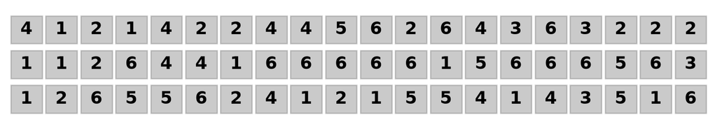

Where was the casino cheating?

[^1]: Durbin et al. (1998)

## The occasionally dishonest casino

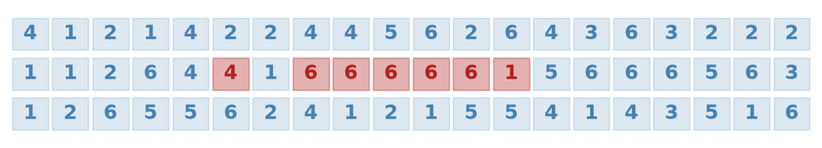

Red: loaded die; blue: fair die

- Long runs with lots of sixes are easy to spot
- Short runs, and exactly where runs start and end, are hard

**An HMM has three parts**

1. *Hidden states*: Fair or Loaded
2. *Transition probabilities*: the chance of each state at the next roll, given the state now
3. *Emission probabilities*: the chance of each roll, given the state

Plus *start probabilities* for the first roll

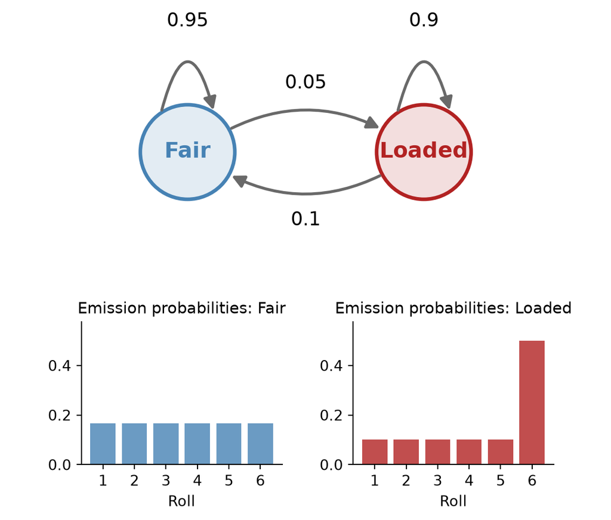

The hidden states are a **Markov chain**, just like a site in our substitution models, but along a sequence instead of through time; we just can’t see it!

## The probability of the rolls *and* a path

A *path* is a sequence of hidden states, one per roll

$$P(\texttt{266}, \text{Fair Loaded Loaded}) =
\underbrace{0.5}_{\text{start F}}
\underbrace{\tfrac{1}{6}}_{\text{F rolls 2}}
\underbrace{0.05}_{\text{F}\rightarrow\text{L}}
\underbrace{0.5}_{\text{L rolls 6}}
\underbrace{0.9}_{\text{L}\rightarrow\text{L}}
\underbrace{0.5}_{\text{L rolls 6}}
\approx 0.00094$$

With many rolls, this gets tiny, so we use **logs** (just like tree likelihoods):

$$\log P(x, \pi) = \log s_{\pi_1} + \log e_{\pi_1}(x_1) +
\sum_{i = 2}^{n} \Big[ \log a_{\pi_{i - 1} \pi_i} + \log e_{\pi_i}(x_i) \Big]$$

# Finding the best path

## How many paths are there?

Each roll could be fair or loaded

| Rolls | Possible paths |
| --- | --- |
| 3 | $2^3 = 8$ |
| 30 | $2^{30} \approx 10^9$ |
| 300 | $2^{300} \approx 2 \times 10^{90}$ |
| 1,000,000 bases of DNA | $2^{1{,}000{,}000}$ |

More paths than atoms in the universe ($\approx 10^{80}$), just like trees; we can’t try them all!

## The Viterbi algorithm<sup>1</sup>

**Key idea**: The best path that ends in state $k$ at roll $i$ came through **some** state $j$ at roll $i - 1$, along the best path that ends in $j$

So, we only need the best path ending in **each state**, at **each roll**

We fill in a table with one row per state and one column per roll

1. **First column**: $V_k(1) = \log s_k + \log e_k(x_1)$
2. **Each later column**: $V_k(i) = \max_j \big[ V_j(i - 1) + \log a_{jk} \big] + \log e_k(x_i)$, and remember the best $j$ (a *pointer*)
3. **Traceback**: Start at the best score in the last column, and follow the pointers backward
[^2]: Viterbi (1967)

## Viterbi, step by step

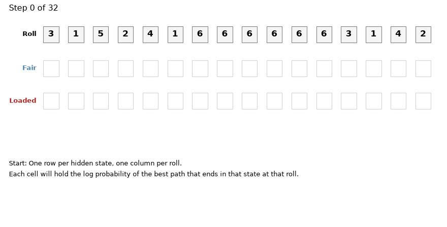

## Haven’t we seen this before?

|  | Fills in a table… | At each cell… | Then… |
| --- | --- | --- | --- |
| **Alignment** | one cell per pair of positions | takes the **best** of 3 moves | traces back |
| **Viterbi** | one cell per state and position | takes the **best** previous state | traces back |
| **Pruning** | one row per node | **adds up** over the hidden bases of each child | averages at the root |
| *Forward algorithm* | one cell per state and position | **adds up** over previous states | sums the last column |

All four are *dynamic programming*: Solve a big problem by building up answers to small ones, and reuse them

## Most probable ≠ true

For the 300 rolls in the exercise:

| Path | Log probability |
| --- | --- |
| Viterbi | $-543.1$ |
| Always fair | $-553.6$ |
| **The true path** | $-583.5$ |

- The true path switches dice many times, and each switch is improbable
- The casino doesn’t always do the most probable thing!
- Still, the Viterbi path has the right die for **85%** of the rolls (“always fair”: 66%)

## How different are the dice?

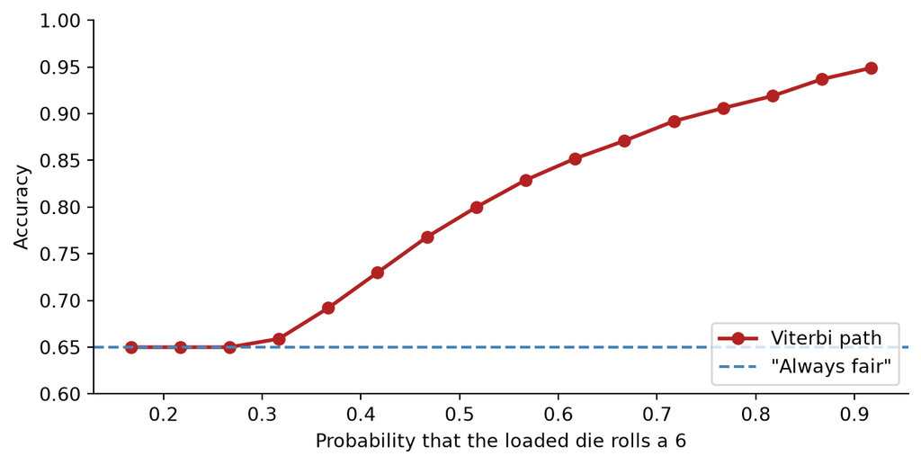

We can only recover hidden states if they emit **different** things

# CpG islands

## CpG depletion

- A *CpG* is a C followed by a G on the same strand
- In vertebrates, most CpG C’s are **methylated**, and methylated C’s easily mutate to T

| CpGs in 2 Mb of human chromosome 19 | Observed/expected |
| --- | --- |
| Whole stretch | 0.45 |
| Background | 0.38 |
| CpG islands | 0.78 |

*CpG islands*: stretches of a few hundred to a few thousand bases where CpGs are **not** depleted, often where genes start (Gardiner-Garden and Frommer 1987)

## Training an HMM by counting

When we have data with known hidden states, we can train an HMM by just **counting**:

- $e_k(s) = \dfrac{\text{times state } k \text{ emitted } s}{\text{positions in state } k}$
- $a_{jk} = \dfrac{\text{times state } j \text{ was followed by } k}{\text{times state } j \text{ was followed by anything}}$
- Train on the **first** million bases, test on the **second** million
- Start every count at 1 (a *pseudocount*), so no probability is 0

## One base at a time, or pairs?

|  | One base | Pairs |
| --- | --- | --- |
| Accuracy | 0.921 | **0.959** |
| (Everything background) | 0.928 | 0.928 |
| UCSC islands found (of 109) | 65 | **70** |
| HMM islands that are real | 60 of 75 | **72 of 85** |

- One base at a time: the HMM can only see **GC content**
- Pairs: within each hidden state, the bases follow a Markov chain, $P(\text{base} \mid \text{previous base})$, so it can see **CpGs**
- $P(\texttt{G} \mid \texttt{C})$: 0.11 in the background, 0.28 in islands

We use the **same** `viterbi` function as the casino! And 27 of 29 genes start near an HMM island.

# HMMs are everywhere

## HMMs in genomics

| Problem | Hidden states | Observations |
| --- | --- | --- |
| Gene finding (GENSCAN) (Burge and Karlin 1997) | exon, intron, intergenic, … | bases |
| Protein families (Pfam, HMMER) (Krogh et al. 1994; Eddy 2011) | match, insert, delete | amino acids |
| Conserved elements (phastCons) (Siepel et al. 2005) | conserved or not | alignment columns |
| Chromatin states (ChromHMM) (Ernst and Kellis 2012) | promoter, enhancer, … | histone marks |
| Population history (PSMC) (Li and Durbin 2011) | time to common ancestor | heterozygous sites |

The first HMM for DNA split sequences into stretches with different base compositions (Churchill 1989), a lot like our CpG islands

## Beyond genomics

| Problem | Hidden states | Observations |
| --- | --- | --- |
| Animal movement (Langrock et al. 2012) | resting, foraging, traveling | step lengths, turning angles |
| Speech recognition (Rabiner 1989) | sounds, words | audio |
| Digital communication (Viterbi 1967) | the bits that were sent | a noisy signal |

Viterbi invented his algorithm to decode noisy digital signals, like those sent to cell phones and from spacecraft; we’re using it to read genomes!

## Phylo-HMMs: HMMs meet pruning

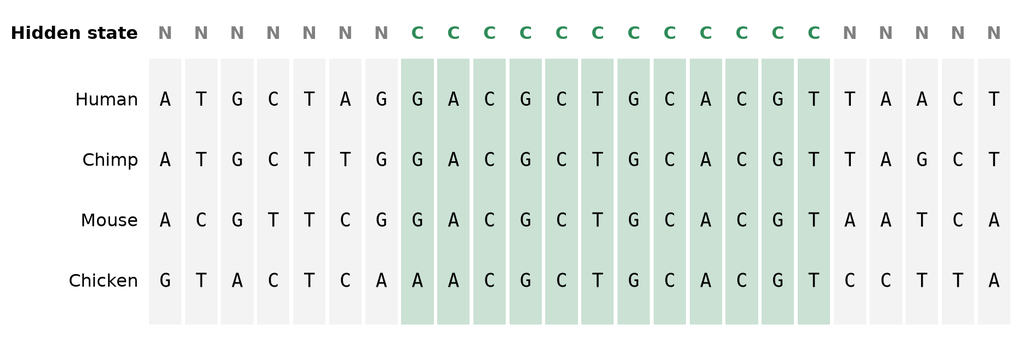

- Hidden states: **C**onserved (evolving slowly) or **N**ot
- Emission probability of a column = the probability of the column on the tree, from the **pruning algorithm**, with short branches in the conserved state (Siepel et al. 2005)

## What about genes?

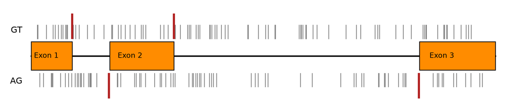

- *HBB* (β-globin): gray: all 87 GTs and 81 AGs; red: the 2 real starts and 2 real ends of introns
- A simple exon/intron HMM did **worse** than calling everything intron on chromosome 19 (65% vs. 78%)
- Real gene finders use codon models, separate parameters for GC-rich and GC-poor DNA (Burge and Karlin 1997), and models of **splice sites**

## Summary

- An **HMM** has hidden **states** that follow a Markov chain (**transitions**), and **emit** what we can see (**emissions**)
- The **Viterbi algorithm** finds the most probable path of hidden states by dynamic programming: fill in a table, then trace back
- Max ↔︎ sum: Viterbi is like alignment; the forward algorithm is like pruning
- The most probable path isn’t the true path, and we can only recover hidden states that emit different things
- When we have data with known states, we can **train** an HMM by **counting**
- The same code finds loaded dice, CpG islands, genes, protein domains, conserved elements, …

## In the exercise

1. `simulate_hmm`: Simulate a night at the casino
2. `log_joint_probability`: How probable are the rolls and a path?
3. `viterbi_step` and `viterbi`: Catch the casino cheating
4. `plot_paths`: Plot the true and Viterbi paths
5. `train_hmm`: Learn an HMM by counting, and find CpG islands in a human chromosome

**Watch for**

How many sixes in a row does it take to convince an HMM the die is loaded?

## Exercise

1. Log into [molab](https://molab.marimo.io/)
2. [Open the exercise in molab](https://molab.marimo.io/github/phyletica/intro-to-comp-bio/blob/main/notebooks/nb-10-hmm/hidden_markov_models.py)
3. Click “Fork” button

# References

Burge, Chris, and Samuel Karlin. 1997. “Prediction of Complete Gene Structures in Human Genomic DNA.” *Journal of Molecular Biology* 268 (1): 78–94. https://doi.org/10.1006/jmbi.1997.0951.

Churchill, Gary A. 1989. “Stochastic Models for Heterogeneous DNA Sequences.” *Bulletin of Mathematical Biology* 51 (1): 79–94. https://doi.org/10.1007/BF02458837.

Durbin, Richard, Sean R. Eddy, Anders Krogh, and Graeme Mitchison. 1998. *Biological Sequence Analysis: Probabilistic Models of Proteins and Nucleic Acids*. Cambridge University Press.

Eddy, Sean R. 2011. “Accelerated Profile HMM Searches.” *PLoS Computational Biology* 7 (10): e1002195. https://doi.org/10.1371/journal.pcbi.1002195.

Ernst, Jason, and Manolis Kellis. 2012. “ChromHMM: Automating Chromatin-State Discovery and Characterization.” *Nature Methods* 9 (3): 215–16. https://doi.org/10.1038/nmeth.1906.

Gardiner-Garden, M., and M. Frommer. 1987. “CpG Islands in Vertebrate Genomes.” *Journal of Molecular Biology* 196 (2): 261–82. https://doi.org/10.1016/0022-2836(87)90689-9.

Krogh, Anders, Michael Brown, I. Saira Mian, Kimmen Sjölander, and David Haussler. 1994. “Hidden Markov Models in Computational Biology: Applications to Protein Modeling.” *Journal of Molecular Biology* 235 (5): 1501–31. https://doi.org/10.1006/jmbi.1994.1104.

Langrock, Roland, Ruth King, Jason Matthiopoulos, Len Thomas, Daniel Fortin, and Juan M. Morales. 2012. “Flexible and Practical Modeling of Animal Telemetry Data: Hidden Markov Models and Extensions.” *Ecology* 93 (11): 2336–42. https://doi.org/10.1890/11-2241.1.

Li, Heng, and Richard Durbin. 2011. “Inference of Human Population History from Individual Whole-Genome Sequences.” *Nature* 475 (7357): 493–96. https://doi.org/10.1038/nature10231.

Rabiner, Lawrence R. 1989. “A Tutorial on Hidden Markov Models and Selected Applications in Speech Recognition.” *Proceedings of the IEEE* 77 (2): 257–86. https://doi.org/10.1109/5.18626.

Siepel, Adam, Gill Bejerano, Jakob S. Pedersen, et al. 2005. “Evolutionarily Conserved Elements in Vertebrate, Insect, Worm, and Yeast Genomes.” *Genome Research* 15 (8): 1034–50. https://doi.org/10.1101/gr.3715005.

Viterbi, Andrew J. 1967. “Error Bounds for Convolutional Codes and an Asymptotically Optimum Decoding Algorithm.” *IEEE Transactions on Information Theory* 13 (2): 260–69. https://doi.org/10.1109/TIT.1967.1054010.

## Acknowledgements

I drafted and iterated on these slides in collaboration with Anthropic’s Claude (Opus 5.5 model).